# Project: FBI NICS Guns Check

[figure not shown]

- Introduction
- Data Wrangling
- Exploratory Data Analysis
- Conclusions

## Introduction

### The project utilizes two database files. One includes data from NICS firearm checks (loaded as `guns.csv`) and the other (`census.csv`) includes population aspects that I will try to link to the former data file.

### As per Github link to this database **[Github](https://github.com/BuzzFeedNews/nics-firearm-background-checks/blob/master/README.md)** descriping The NICS system :

> Mandated by the Brady Handgun Violence Prevention Act of 1993 and launched by the FBI on November 30, 1998, NICS is used by Federal Firearms Licensees (FFLs) to instantly determine whether a prospective buyer is eligible to buy firearms or explosives. Before ringing up the sale, cashiers call in a check to the FBI or to other designated agencies to ensure that each customer does not have a criminal record or isn’t otherwise ineligible to make a purchase. More than 100 million such checks have been made in the last decade, leading to more than 700,000 denials.

### It also states limitation for the guns registeration system to be used as an indication of total guns sold:

> These statistics represent the number of firearm background checks initiated through the NICS They do not represent the number of firearms sold Based on varying state laws and purchase scenarios, a one-to-one correlation cannot be made between a firearm background check and a firearm sale

> A forthcoming study conducted by Harvard researchers found that roughly 40 percent of respondents had acquired their most recent firearm without going through a background check

### Census data base

> The U.S. census data is found in a .csv file. It contains several variables at the state level. Most variables just have one data point per state (2016), but a few have data for more than one year.

### So, *The plan* here is as follows:

- Load both guns and census data files.
- Clean both database.
- Get insights from `guns.csv`
- Filter `census.csv` for 2016 data to get insights from it.
- Merge it with `guns.csv` and get the `guns_per_capita` parameter.
- Examine which parameter correlates most with the `guns_per_capita`

```python
# Importing and loading data files
import pandas as pd
import numpy as np
%matplotlib inline
import matplotlib.pyplot as plt
```

### Questions That can be asked from this data file

[figure not shown]

Q1: Which states have had the highest growth in gun registrations?  
Q2: Which states have the hightest regestered guns from 1998 to 2020?  
Q3: What is the Guns Registeration Year 2020?  
Q4: What is the trend of total guns registeration over time?  
Q5: What is the trend of guns registeration in the state Louisiana and Texas?  
Q6: What census data is most associated with high gun per capita?  
Q7: What is the distribution of the total registerations of guns? (Resubmission Note)

## Data Wrangling

[figure not shown]

### General Properties

```python
# Load your data and print out a few lines. Perform operations to inspect data
#   types and look for instances of missing or possibly errant data.
guns = pd.read_csv('gun_data.csv')
census = pd.read_csv('census.csv')
```

### `Gun Data`

```python
guns.info()
```

```
<class 'pandas.core.frame.DataFrame'>
RangeIndex: 14520 entries, 0 to 14519
Data columns (total 27 columns):
month                        14520 non-null object
state                        14520 non-null object
permit                       14496 non-null float64
permit_recheck               3135 non-null float64
handgun                      14500 non-null float64
long_gun                     14501 non-null float64
other                        7535 non-null float64
multiple                     14520 non-null int64
admin                        14497 non-null float64
prepawn_handgun              12577 non-null float64
prepawn_long_gun             12575 non-null float64
prepawn_other                7150 non-null float64
redemption_handgun           12580 non-null float64
redemption_long_gun          12579 non-null float64
redemption_other             7150 non-null float64
returned_handgun             4235 non-null float64
returned_long_gun            4180 non-null float64
returned_other               3850 non-null float64
rentals_handgun              3025 non-null float64
rentals_long_gun             2860 non-null float64
private_sale_handgun         4785 non-null float64
private_sale_long_gun        4785 non-null float64
private_sale_other           4785 non-null float64
return_to_seller_handgun     4510 non-null float64
return_to_seller_long_gun    4785 non-null float64
return_to_seller_other       4290 non-null float64
totals                       14520 non-null int64
dtypes: float64(23), int64(2), object(2)
memory usage: 3.0+ MB
```

- We need to convert `month` column into `datetime` format

```python
guns.tail()
```

|  | month | state | permit | permit_recheck | handgun | long_gun | other | multiple | admin | prepawn_handgun | ... | returned_other | rentals_handgun | rentals_long_gun | private_sale_handgun | private_sale_long_gun | private_sale_other | return_to_seller_handgun | return_to_seller_long_gun | return_to_seller_other | totals |
| --- | --- | --- | --- | --- | --- | --- | --- | --- | --- | --- | --- | --- | --- | --- | --- | --- | --- | --- | --- | --- | --- |
| 14515 | 1998-11 | Virginia | 0.0 | NaN | 14.0 | 2.0 | NaN | 8 | 0.0 | NaN | ... | NaN | NaN | NaN | NaN | NaN | NaN | NaN | NaN | NaN | 24 |
| 14516 | 1998-11 | Washington | 1.0 | NaN | 65.0 | 286.0 | NaN | 8 | 1.0 | NaN | ... | NaN | NaN | NaN | NaN | NaN | NaN | NaN | NaN | NaN | 361 |
| 14517 | 1998-11 | West Virginia | 3.0 | NaN | 149.0 | 251.0 | NaN | 5 | 0.0 | NaN | ... | NaN | NaN | NaN | NaN | NaN | NaN | NaN | NaN | NaN | 408 |
| 14518 | 1998-11 | Wisconsin | 0.0 | NaN | 25.0 | 214.0 | NaN | 2 | 0.0 | NaN | ... | NaN | NaN | NaN | NaN | NaN | NaN | NaN | NaN | NaN | 241 |
| 14519 | 1998-11 | Wyoming | 8.0 | NaN | 45.0 | 49.0 | NaN | 5 | 0.0 | NaN | ... | NaN | NaN | NaN | NaN | NaN | NaN | NaN | NaN | NaN | 107 |

5 rows × 27 columns

- There are many `NaN` values in the data file. We need to fill them with zeros but first we need to verify that `totals` column really equal the summation of each row.

```python
guns.head()
```

|  | month | state | permit | permit_recheck | handgun | long_gun | other | multiple | admin | prepawn_handgun | ... | returned_other | rentals_handgun | rentals_long_gun | private_sale_handgun | private_sale_long_gun | private_sale_other | return_to_seller_handgun | return_to_seller_long_gun | return_to_seller_other | totals |
| --- | --- | --- | --- | --- | --- | --- | --- | --- | --- | --- | --- | --- | --- | --- | --- | --- | --- | --- | --- | --- | --- |
| 0 | 2020-10 | Alabama | 32038.0 | 585.0 | 24084.0 | 17964.0 | 1698.0 | 1104 | 0.0 | 28.0 | ... | 0.0 | 0.0 | 0.0 | 28.0 | 25.0 | 7.0 | 1.0 | 4.0 | 1.0 | 80934 |
| 1 | 2020-10 | Alaska | 264.0 | 1.0 | 3209.0 | 3210.0 | 348.0 | 188 | 0.0 | 0.0 | ... | 0.0 | 0.0 | 0.0 | 6.0 | 13.0 | 1.0 | 1.0 | 0.0 | 0.0 | 7564 |
| 2 | 2020-10 | Arizona | 8991.0 | 1015.0 | 24964.0 | 12288.0 | 1951.0 | 1762 | 0.0 | 9.0 | ... | 1.0 | 0.0 | 0.0 | 19.0 | 13.0 | 0.0 | 0.0 | 1.0 | 0.0 | 52521 |
| 3 | 2020-10 | Arkansas | 5108.0 | 549.0 | 8931.0 | 9386.0 | 567.0 | 421 | 8.0 | 9.0 | ... | 0.0 | 0.0 | 0.0 | 15.0 | 7.0 | 4.0 | 0.0 | 0.0 | 0.0 | 27177 |
| 4 | 2020-10 | California | 36719.0 | 0.0 | 65376.0 | 40286.0 | 8319.0 | 0 | 0.0 | 0.0 | ... | 0.0 | 0.0 | 0.0 | 0.0 | 0.0 | 0.0 | 0.0 | 0.0 | 0.0 | 151359 |

5 rows × 27 columns

### `Census Data`

```python
census.info()
```

```
<class 'pandas.core.frame.DataFrame'>
RangeIndex: 85 entries, 0 to 84
Data columns (total 52 columns):
Fact              80 non-null object
Fact Note         28 non-null object
Alabama           65 non-null object
Alaska            65 non-null object
Arizona           65 non-null object
Arkansas          65 non-null object
California        65 non-null object
Colorado          65 non-null object
Connecticut       65 non-null object
Delaware          65 non-null object
Florida           65 non-null object
Georgia           65 non-null object
Hawaii            65 non-null object
Idaho             65 non-null object
Illinois          65 non-null object
Indiana           65 non-null object
Iowa              65 non-null object
Kansas            65 non-null object
Kentucky          65 non-null object
Louisiana         65 non-null object
Maine             65 non-null object
Maryland          65 non-null object
Massachusetts     65 non-null object
Michigan          65 non-null object
Minnesota         65 non-null object
Mississippi       65 non-null object
Missouri          65 non-null object
Montana           65 non-null object
Nebraska          65 non-null object
Nevada            65 non-null object
New Hampshire     65 non-null object
New Jersey        65 non-null object
New Mexico        65 non-null object
New York          65 non-null object
North Carolina    65 non-null object
North Dakota      65 non-null object
Ohio              65 non-null object
Oklahoma          65 non-null object
Oregon            65 non-null object
Pennsylvania      65 non-null object
Rhode Island      65 non-null object
South Carolina    65 non-null object
South Dakota      65 non-null object
Tennessee         65 non-null object
Texas             65 non-null object
Utah              65 non-null object
Vermont           65 non-null object
Virginia          65 non-null object
Washington        65 non-null object
West Virginia     65 non-null object
Wisconsin         65 non-null object
Wyoming           65 non-null object
dtypes: object(52)
memory usage: 34.6+ KB
```

```python
census.head()
```

|  | Fact | Fact Note | Alabama | Alaska | Arizona | Arkansas | California | Colorado | Connecticut | Delaware | ... | South Dakota | Tennessee | Texas | Utah | Vermont | Virginia | Washington | West Virginia | Wisconsin | Wyoming |
| --- | --- | --- | --- | --- | --- | --- | --- | --- | --- | --- | --- | --- | --- | --- | --- | --- | --- | --- | --- | --- | --- |
| 0 | Population estimates, July 1, 2016, (V2016) | NaN | 4,863,300 | 741,894 | 6,931,071 | 2,988,248 | 39,250,017 | 5,540,545 | 3,576,452 | 952,065 | ... | 865454 | 6651194 | 27,862,596 | 3,051,217 | 624,594 | 8,411,808 | 7,288,000 | 1,831,102 | 5,778,708 | 585,501 |
| 1 | Population estimates base, April 1, 2010, (V2... | NaN | 4,780,131 | 710,249 | 6,392,301 | 2,916,025 | 37,254,522 | 5,029,324 | 3,574,114 | 897,936 | ... | 814195 | 6346298 | 25,146,100 | 2,763,888 | 625,741 | 8,001,041 | 6,724,545 | 1,853,011 | 5,687,289 | 563,767 |
| 2 | Population, percent change - April 1, 2010 (es... | NaN | 1.70% | 4.50% | 8.40% | 2.50% | 5.40% | 10.20% | 0.10% | 6.00% | ... | 0.063 | 0.048 | 10.80% | 10.40% | -0.20% | 5.10% | 8.40% | -1.20% | 1.60% | 3.90% |
| 3 | Population, Census, April 1, 2010 | NaN | 4,779,736 | 710,231 | 6,392,017 | 2,915,918 | 37,253,956 | 5,029,196 | 3,574,097 | 897,934 | ... | 814180 | 6346105 | 25,145,561 | 2,763,885 | 625,741 | 8,001,024 | 6,724,540 | 1,852,994 | 5,686,986 | 563,626 |
| 4 | Persons under 5 years, percent, July 1, 2016, ... | NaN | 6.00% | 7.30% | 6.30% | 6.40% | 6.30% | 6.10% | 5.20% | 5.80% | ... | 0.071 | 0.061 | 7.20% | 8.30% | 4.90% | 6.10% | 6.20% | 5.50% | 5.80% | 6.50% |

5 rows × 52 columns

For this data file we would like to do the following:

### Data Cleaning

[figure not shown]

#### A. guns.csv

```python
# After discussing the structure of the data and any problems that need to be
#   cleaned, perform those cleaning steps in the second part of this section.
guns.month = pd.to_datetime(guns.month) # converting month into datetime type
```

Checking if the 'totals' is equal to the summation each row..

```python
(guns.loc[:,'permit':'return_to_seller_other'].sum(axis = 1) - guns['totals']).unique()
```

```
array([ 0.])
```

> **Seems about right. We can then fill the NaN values with zeros.**

```python
guns.fillna(0, inplace =True)
guns.tail()
```

|  | month | state | permit | permit_recheck | handgun | long_gun | other | multiple | admin | prepawn_handgun | ... | returned_other | rentals_handgun | rentals_long_gun | private_sale_handgun | private_sale_long_gun | private_sale_other | return_to_seller_handgun | return_to_seller_long_gun | return_to_seller_other | totals |
| --- | --- | --- | --- | --- | --- | --- | --- | --- | --- | --- | --- | --- | --- | --- | --- | --- | --- | --- | --- | --- | --- |
| 14515 | 1998-11-01 | Virginia | 0.0 | 0.0 | 14.0 | 2.0 | 0.0 | 8 | 0.0 | 0.0 | ... | 0.0 | 0.0 | 0.0 | 0.0 | 0.0 | 0.0 | 0.0 | 0.0 | 0.0 | 24 |
| 14516 | 1998-11-01 | Washington | 1.0 | 0.0 | 65.0 | 286.0 | 0.0 | 8 | 1.0 | 0.0 | ... | 0.0 | 0.0 | 0.0 | 0.0 | 0.0 | 0.0 | 0.0 | 0.0 | 0.0 | 361 |
| 14517 | 1998-11-01 | West Virginia | 3.0 | 0.0 | 149.0 | 251.0 | 0.0 | 5 | 0.0 | 0.0 | ... | 0.0 | 0.0 | 0.0 | 0.0 | 0.0 | 0.0 | 0.0 | 0.0 | 0.0 | 408 |
| 14518 | 1998-11-01 | Wisconsin | 0.0 | 0.0 | 25.0 | 214.0 | 0.0 | 2 | 0.0 | 0.0 | ... | 0.0 | 0.0 | 0.0 | 0.0 | 0.0 | 0.0 | 0.0 | 0.0 | 0.0 | 241 |
| 14519 | 1998-11-01 | Wyoming | 8.0 | 0.0 | 45.0 | 49.0 | 0.0 | 5 | 0.0 | 0.0 | ... | 0.0 | 0.0 | 0.0 | 0.0 | 0.0 | 0.0 | 0.0 | 0.0 | 0.0 | 107 |

5 rows × 27 columns

```python
guns.info()
```

```
<class 'pandas.core.frame.DataFrame'>
RangeIndex: 14520 entries, 0 to 14519
Data columns (total 27 columns):
month                        14520 non-null datetime64[ns]
state                        14520 non-null object
permit                       14520 non-null float64
permit_recheck               14520 non-null float64
handgun                      14520 non-null float64
long_gun                     14520 non-null float64
other                        14520 non-null float64
multiple                     14520 non-null int64
admin                        14520 non-null float64
prepawn_handgun              14520 non-null float64
prepawn_long_gun             14520 non-null float64
prepawn_other                14520 non-null float64
redemption_handgun           14520 non-null float64
redemption_long_gun          14520 non-null float64
redemption_other             14520 non-null float64
returned_handgun             14520 non-null float64
returned_long_gun            14520 non-null float64
returned_other               14520 non-null float64
rentals_handgun              14520 non-null float64
rentals_long_gun             14520 non-null float64
private_sale_handgun         14520 non-null float64
private_sale_long_gun        14520 non-null float64
private_sale_other           14520 non-null float64
return_to_seller_handgun     14520 non-null float64
return_to_seller_long_gun    14520 non-null float64
return_to_seller_other       14520 non-null float64
totals                       14520 non-null int64
dtypes: datetime64[ns](1), float64(23), int64(2), object(1)
memory usage: 3.0+ MB
```

```python
guns.duplicated().all() #Checking Duplicates
```

```
False
```

```python
guns.isna().all() #checking Nan
```

```
month                        False
state                        False
permit                       False
permit_recheck               False
handgun                      False
long_gun                     False
other                        False
multiple                     False
admin                        False
prepawn_handgun              False
prepawn_long_gun             False
prepawn_other                False
redemption_handgun           False
redemption_long_gun          False
redemption_other             False
returned_handgun             False
returned_long_gun            False
returned_other               False
rentals_handgun              False
rentals_long_gun             False
private_sale_handgun         False
private_sale_long_gun        False
private_sale_other           False
return_to_seller_handgun     False
return_to_seller_long_gun    False
return_to_seller_other       False
totals                       False
dtype: bool
```

#### B. Census Data

Dropping irrelevant column and row

```python
census.drop('Fact Note', axis = 1, inplace = True)
census.drop([64], inplace = True)
```

```python
census.head()
```

|  | Fact | Alabama | Alaska | Arizona | Arkansas | California | Colorado | Connecticut | Delaware | Florida | ... | South Dakota | Tennessee | Texas | Utah | Vermont | Virginia | Washington | West Virginia | Wisconsin | Wyoming |
| --- | --- | --- | --- | --- | --- | --- | --- | --- | --- | --- | --- | --- | --- | --- | --- | --- | --- | --- | --- | --- | --- |
| 0 | Population estimates, July 1, 2016, (V2016) | 4,863,300 | 741,894 | 6,931,071 | 2,988,248 | 39,250,017 | 5,540,545 | 3,576,452 | 952,065 | 20,612,439 | ... | 865454 | 6651194 | 27,862,596 | 3,051,217 | 624,594 | 8,411,808 | 7,288,000 | 1,831,102 | 5,778,708 | 585,501 |
| 1 | Population estimates base, April 1, 2010, (V2... | 4,780,131 | 710,249 | 6,392,301 | 2,916,025 | 37,254,522 | 5,029,324 | 3,574,114 | 897,936 | 18,804,592 | ... | 814195 | 6346298 | 25,146,100 | 2,763,888 | 625,741 | 8,001,041 | 6,724,545 | 1,853,011 | 5,687,289 | 563,767 |
| 2 | Population, percent change - April 1, 2010 (es... | 1.70% | 4.50% | 8.40% | 2.50% | 5.40% | 10.20% | 0.10% | 6.00% | 9.60% | ... | 0.063 | 0.048 | 10.80% | 10.40% | -0.20% | 5.10% | 8.40% | -1.20% | 1.60% | 3.90% |
| 3 | Population, Census, April 1, 2010 | 4,779,736 | 710,231 | 6,392,017 | 2,915,918 | 37,253,956 | 5,029,196 | 3,574,097 | 897,934 | 18,801,310 | ... | 814180 | 6346105 | 25,145,561 | 2,763,885 | 625,741 | 8,001,024 | 6,724,540 | 1,852,994 | 5,686,986 | 563,626 |
| 4 | Persons under 5 years, percent, July 1, 2016, ... | 6.00% | 7.30% | 6.30% | 6.40% | 6.30% | 6.10% | 5.20% | 5.80% | 5.50% | ... | 0.071 | 0.061 | 7.20% | 8.30% | 4.90% | 6.10% | 6.20% | 5.50% | 5.80% | 6.50% |

5 rows × 51 columns

Dropping NaN

```python
census.dropna(inplace = True)
```

Replace commas and replace `Value Flags` with 0

```python
census.iloc[:,1:] = census.iloc[:,1:].apply(lambda x: x.str.replace(',','').str.strip(' ').str.strip('$').str.replace('D','0').str.replace('FN','0').str.replace('Z','0').str.strip('-'))
```

**Percent values in Census is not consistant (some is written in `'%'` and some in decimal) so we need to remove `%` and divide by 100 for those values**

```python
def per_remove(x): #Percent values in Census is not consistant (some is written in `'%'` and some in decimal) so we need to remove `%` and divide by 100 for those values
    x[x.str.contains('%')]=x[x.str.contains('%')].str.strip('%').astype('float')/100
    return x
census = census.apply(per_remove)
```

```python
census.info()
```

```
<class 'pandas.core.frame.DataFrame'>
Int64Index: 64 entries, 0 to 63
Data columns (total 51 columns):
Fact              64 non-null object
Alabama           64 non-null object
Alaska            64 non-null object
Arizona           64 non-null object
Arkansas          64 non-null object
California        64 non-null object
Colorado          64 non-null object
Connecticut       64 non-null object
Delaware          64 non-null object
Florida           64 non-null object
Georgia           64 non-null object
Hawaii            64 non-null object
Idaho             64 non-null object
Illinois          64 non-null object
Indiana           64 non-null object
Iowa              64 non-null object
Kansas            64 non-null object
Kentucky          64 non-null object
Louisiana         64 non-null object
Maine             64 non-null object
Maryland          64 non-null object
Massachusetts     64 non-null object
Michigan          64 non-null object
Minnesota         64 non-null object
Mississippi       64 non-null object
Missouri          64 non-null object
Montana           64 non-null object
Nebraska          64 non-null object
Nevada            64 non-null object
New Hampshire     64 non-null object
New Jersey        64 non-null object
New Mexico        64 non-null object
New York          64 non-null object
North Carolina    64 non-null object
North Dakota      64 non-null object
Ohio              64 non-null object
Oklahoma          64 non-null object
Oregon            64 non-null object
Pennsylvania      64 non-null object
Rhode Island      64 non-null object
South Carolina    64 non-null object
South Dakota      64 non-null object
Tennessee         64 non-null object
Texas             64 non-null object
Utah              64 non-null object
Vermont           64 non-null object
Virginia          64 non-null object
Washington        64 non-null object
West Virginia     64 non-null object
Wisconsin         64 non-null object
Wyoming           64 non-null object
dtypes: object(51)
memory usage: 28.5+ KB
```

**Converting the numerical columns into float type**

```python
for col in census.iloc[:,1:].columns:
    census[col] = census[col].astype(float)
```

```python
census.info()
```

```
<class 'pandas.core.frame.DataFrame'>
Int64Index: 64 entries, 0 to 63
Data columns (total 51 columns):
Fact              64 non-null object
Alabama           64 non-null float64
Alaska            64 non-null float64
Arizona           64 non-null float64
Arkansas          64 non-null float64
California        64 non-null float64
Colorado          64 non-null float64
Connecticut       64 non-null float64
Delaware          64 non-null float64
Florida           64 non-null float64
Georgia           64 non-null float64
Hawaii            64 non-null float64
Idaho             64 non-null float64
Illinois          64 non-null float64
Indiana           64 non-null float64
Iowa              64 non-null float64
Kansas            64 non-null float64
Kentucky          64 non-null float64
Louisiana         64 non-null float64
Maine             64 non-null float64
Maryland          64 non-null float64
Massachusetts     64 non-null float64
Michigan          64 non-null float64
Minnesota         64 non-null float64
Mississippi       64 non-null float64
Missouri          64 non-null float64
Montana           64 non-null float64
Nebraska          64 non-null float64
Nevada            64 non-null float64
New Hampshire     64 non-null float64
New Jersey        64 non-null float64
New Mexico        64 non-null float64
New York          64 non-null float64
North Carolina    64 non-null float64
North Dakota      64 non-null float64
Ohio              64 non-null float64
Oklahoma          64 non-null float64
Oregon            64 non-null float64
Pennsylvania      64 non-null float64
Rhode Island      64 non-null float64
South Carolina    64 non-null float64
South Dakota      64 non-null float64
Tennessee         64 non-null float64
Texas             64 non-null float64
Utah              64 non-null float64
Vermont           64 non-null float64
Virginia          64 non-null float64
Washington        64 non-null float64
West Virginia     64 non-null float64
Wisconsin         64 non-null float64
Wyoming           64 non-null float64
dtypes: float64(50), object(1)
memory usage: 28.5+ KB
```

**Checking column `states` at both data files to be the same**

```python
guns_state = np.array(guns.state.unique())
len(guns_state)
```

```
55
```

```python
census_state = np.array(census.columns[1:])
len(census_state)
```

```
50
```

Find the extra 5 states in `guns`

```python
drop_states = np.setdiff1d(guns_state, census_state)
drop_states
```

```
array(['District of Columbia', 'Guam', 'Mariana Islands', 'Puerto Rico',
       'Virgin Islands'], dtype=object)
```

Normalizing the `states` in both Data Files

```python
for x in drop_states:
    guns.drop(guns[guns.state == x].index ,inplace = True)
```

```python
guns.state.nunique()
```

```
50
```

## Exploratory Data Analysis

[figure not shown]

### Research Question 1 : Which states have had the highest growth in gun registrations?

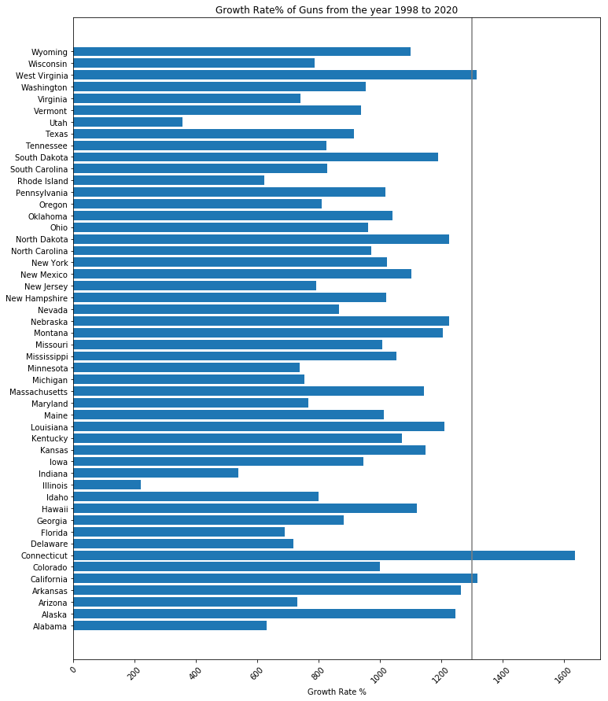

```python
# Calculate growth in guns we will calculate percent of increase between the sum (12 months) over the year 1998 and over the year 2020

states = guns.state.unique() #getting the states list of names

def state_growth(state_name): #defining a function to calculate the growth over any state
    state_start = guns[guns.state == state_name].totals.iloc[12:].sum() # total guns per year (12 months)  2020
    state_end = guns[guns.state == state_name].totals.iloc[:12].sum() # total guns per year (12 months) 1998
    return (state_start - state_end)/ state_end*100

iterator =(state_growth(x) for x in states) #using numpy iterator to get list of state growth
growth_list =np.fromiter (iterator, 'int')
plt.figure(figsize=(12, 15))
plt.barh(states,growth_list)
plt.title('Growth Rate% of Guns from the year 1998 to 2020')
plt.xlabel('Growth Rate %')
plt.axvline(1300, color="gray")
plt.xticks(rotation=45);
```

```python
sorted(zip(growth_list, states))[-3:] #Highest 3 states
```

```
[(1317, 'West Virginia'), (1318, 'California'), (1637, 'Connecticut')]
```

Figure above suggests that **Connecticut, California and West Virginia** stand as the hightest 3 states in guns regesteration growth from 1998 to 2020

### Research Question2: Which states have the hightest regestered guns from 1998 to 2020?

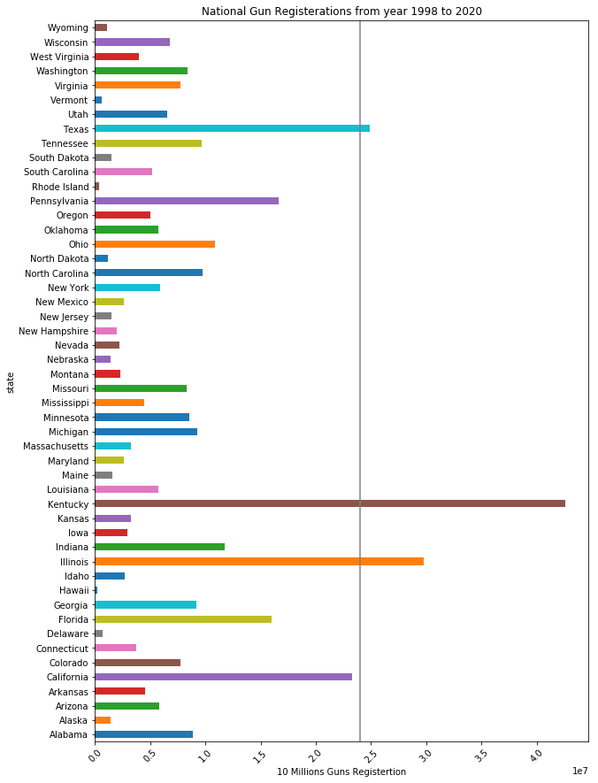

```python
# Continue to explore the data to address your additional research
#   questions. Add more headers as needed if you have more questions to
#   investigate.
plt.subplots(figsize=(10,15))
guns.groupby(guns.state).totals.sum().plot(kind ='barh')
plt.title('National Gun Registerations from year 1998 to 2020')
plt.xlabel('10 Millions Guns Registertion')
plt.axvline(2.4e7, color="gray")
plt.xticks(rotation=45);
```

Figure above suggests that **Kentucky, Illinois and Texas** stand as the hightest 3 states in guns regesteration totals from 1998 to 2020

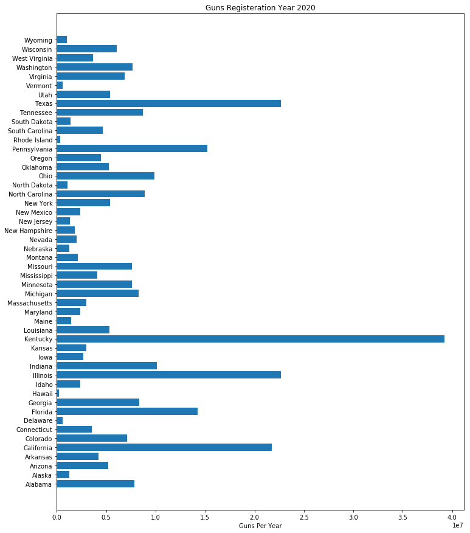

```python
guns_2020=[]
for x in states:
    guns_2020.append (guns[guns.state == x].totals.iloc[12:].sum()) #sum of recent highest 12 months
plt.figure(figsize=(12, 15))
plt.barh(states,guns_2020)
plt.title('Guns Registeration Year 2020')
plt.xlabel('Guns Per Year');
```

### Research Question 4: What is the trend of total guns registeration over time?

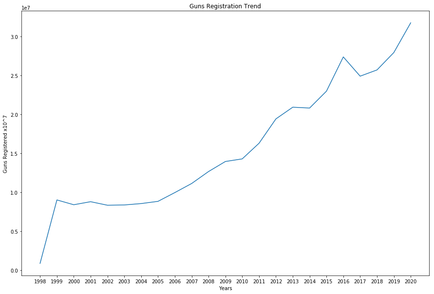

```python
plt.subplots(figsize=(15,10))
guns.groupby(guns.month.dt.year).totals.sum().plot()
plt.xlabel('Years')
plt.ylabel('Guns Registered x10^7')
plt.title('Guns Registration Trend')
plt.xticks(np.arange(1998,2021));
```

### Research Question 5: What is the trend of guns registeration in the state Louisiana and Texas?

Defining function to plot state trend over time

```python
def trend(state):
    plt.subplots(figsize=(15,10))
    ((guns[guns.state == state].groupby(guns.month.dt.year).totals.sum())/guns.groupby(guns.month.dt.year).totals.sum()).plot()
    plt.xlabel('Years')
    plt.ylabel('Percent of National Registerations')
    plt.title(state+' Guns Registration Trend')
    plt.xticks(np.arange(1998,2021));
    return()
```

#### Examining Louisiana

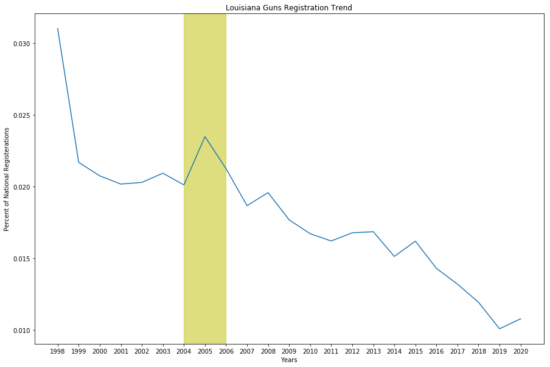

```python
trend('Louisiana')
plt.axvspan(2004, 2006, color='y', alpha=0.5);
```

**an obvious peak can be seen the year 2005 and can be related to hurrican Katrina as per **[New York Magazine](https://www.nytimes.com/interactive/2015/12/10/us/gun-sales-terrorism-obama-restrictions.html)****

#### Examining Texas

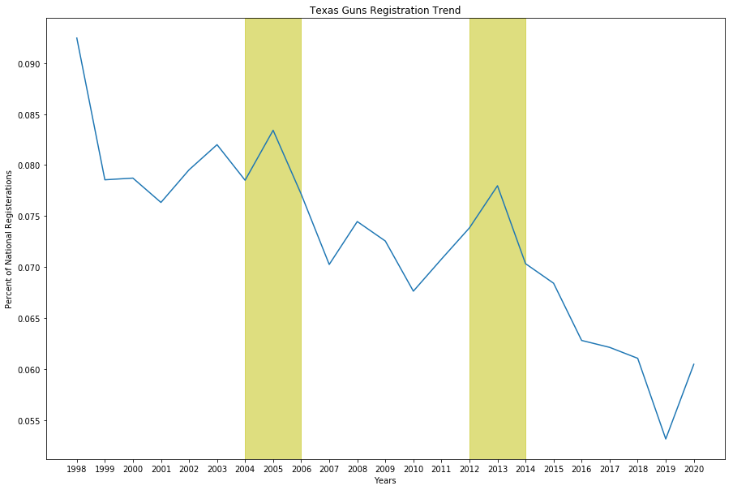

```python
trend('Texas')
plt.axvspan(2004, 2006, color='y', alpha=0.5)
plt.axvspan(2012, 2014, color='y', alpha=0.5);
```

Similare peak could be found in 2005-2006 during hurrican Katrina. another peak can be found at the year end of 2012 and can be correlated to **the Sandy Hook school shooting** **[see here](https://www.cbs19.tv/article/news/local/national-study-shows-gun-sales-on-the-rise-in-the-us-in-texas/503-0f2b622b-1636-4fc2-83e1-d042c1b459a5)**

This can lead us to ask a new question **Have the gun registeration went up after 11/9/2001 terror attack in the US?**

```
''
```

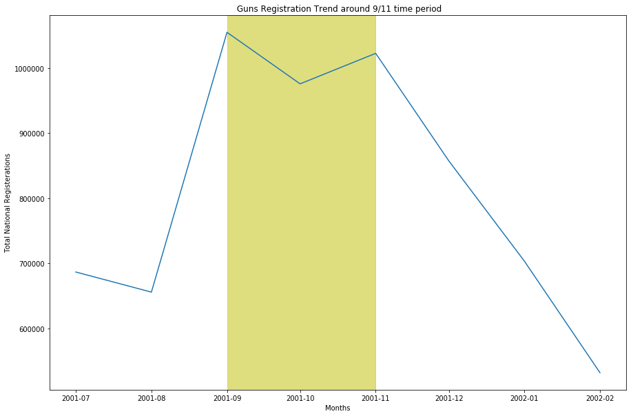

```python
fig, ax =plt.subplots(figsize=(15,10))
months = guns[(guns.month > '2001-06') & (guns.month < '2002-03')]
plt.plot(months.month.unique(), months.groupby(guns.month).totals.sum())
plt.xlabel('Months')
plt.ylabel('Total National Registerations')
plt.title(' Guns Registration Trend around 9/11 time period')
plt.axvspan('2001-09', '2001-11', color='y', alpha=0.5);
;
```

#### There is a peak coincides with `9/11` terror attack

### Research Question 6: What census data is most associated with high gun per capita?

#### To analysis the guns registeration based on the census data we will filter data to 2016 which has the most parameters in census data file

```python
guns_2016 = guns[guns.month == '2016'].groupby(guns.state).sum() #grouping guns for the year 2016 by state
```

```python
guns_2016_totals = guns_2016.drop(guns_2016.columns[0:-1], axis = 1).reset_index()
```

```python
guns_2016_totals
```

|  | state | totals |
| --- | --- | --- |
| 0 | Alabama | 73218 |
| 1 | Alaska | 6085 |
| 2 | Arizona | 31910 |
| 3 | Arkansas | 20437 |
| 4 | California | 220912 |
| 5 | Colorado | 48214 |
| 6 | Connecticut | 31712 |
| 7 | Delaware | 4886 |
| 8 | Florida | 125935 |
| 9 | Georgia | 62707 |
| 10 | Hawaii | 1383 |
| 11 | Idaho | 13197 |
| 12 | Illinois | 189400 |
| 13 | Indiana | 230892 |
| 14 | Iowa | 26714 |
| 15 | Kansas | 19443 |
| 16 | Kentucky | 302383 |
| 17 | Louisiana | 32192 |
| 18 | Maine | 8844 |
| 19 | Maryland | 13321 |
| 20 | Massachusetts | 20208 |
| 21 | Michigan | 56723 |
| 22 | Minnesota | 50842 |
| 23 | Mississippi | 21330 |
| 24 | Missouri | 61257 |
| 25 | Montana | 10722 |
| 26 | Nebraska | 11116 |
| 27 | Nevada | 12291 |
| 28 | New Hampshire | 16887 |
| 29 | New Jersey | 8683 |
| 30 | New Mexico | 12577 |
| 31 | New York | 34071 |
| 32 | North Carolina | 51646 |
| 33 | North Dakota | 5877 |
| 34 | Ohio | 76218 |
| 35 | Oklahoma | 34889 |
| 36 | Oregon | 26378 |
| 37 | Pennsylvania | 102170 |
| 38 | Rhode Island | 2617 |
| 39 | South Carolina | 31396 |
| 40 | South Dakota | 10220 |
| 41 | Tennessee | 62789 |
| 42 | Texas | 164088 |
| 43 | Utah | 19968 |
| 44 | Vermont | 3451 |
| 45 | Virginia | 44181 |
| 46 | Washington | 58050 |
| 47 | West Virginia | 18985 |
| 48 | Wisconsin | 39561 |
| 49 | Wyoming | 5676 |

```python
census_2016 = census[census.Fact.str.contains('2016')]
```

**Transpose `census_2016` to get the states into rows like guns_2016**

```python
census_2016 = census_2016.set_index('Fact').T.reset_index()
```

Renaming `census_2016 columns` to easy access it

```python
census_2016.head()
```

| Fact | index | Population estimates, July 1, 2016, (V2016) | Population estimates base, April 1, 2010, (V2016) | Population, percent change - April 1, 2010 (estimates base) to July 1, 2016, (V2016) | Persons under 5 years, percent, July 1, 2016, (V2016) | Persons under 18 years, percent, July 1, 2016, (V2016) | Persons 65 years and over, percent, July 1, 2016, (V2016) | Female persons, percent, July 1, 2016, (V2016) | White alone, percent, July 1, 2016, (V2016) | Black or African American alone, percent, July 1, 2016, (V2016) | American Indian and Alaska Native alone, percent, July 1, 2016, (V2016) | Asian alone, percent, July 1, 2016, (V2016) | Native Hawaiian and Other Pacific Islander alone, percent, July 1, 2016, (V2016) | Two or More Races, percent, July 1, 2016, (V2016) | Hispanic or Latino, percent, July 1, 2016, (V2016) | White alone, not Hispanic or Latino, percent, July 1, 2016, (V2016) | Housing units, July 1, 2016, (V2016) | Building permits, 2016 |
| --- | --- | --- | --- | --- | --- | --- | --- | --- | --- | --- | --- | --- | --- | --- | --- | --- | --- | --- |
| 0 | Alabama | 4863300.0 | 4780131.0 | 0.017 | 0.060 | 0.226 | 0.161 | 0.516 | 0.693 | 0.268 | 0.007 | 0.014 | 0.001 | 0.016 | 0.042 | 0.658 | 2230185.0 | 15001.0 |
| 1 | Alaska | 741894.0 | 710249.0 | 0.045 | 0.073 | 0.252 | 0.104 | 0.477 | 0.661 | 0.038 | 0.152 | 0.063 | 0.013 | 0.073 | 0.070 | 0.612 | 310658.0 | 1503.0 |
| 2 | Arizona | 6931071.0 | 6392301.0 | 0.084 | 0.063 | 0.235 | 0.169 | 0.503 | 0.833 | 0.049 | 0.054 | 0.034 | 0.003 | 0.028 | 0.309 | 0.555 | 2961003.0 | 35578.0 |
| 3 | Arkansas | 2988248.0 | 2916025.0 | 0.025 | 0.064 | 0.236 | 0.163 | 0.509 | 0.794 | 0.157 | 0.010 | 0.016 | 0.003 | 0.020 | 0.073 | 0.729 | 1354762.0 | 9474.0 |
| 4 | California | 39250017.0 | 37254522.0 | 0.054 | 0.063 | 0.232 | 0.136 | 0.503 | 0.727 | 0.065 | 0.017 | 0.148 | 0.005 | 0.038 | 0.389 | 0.377 | 14060525.0 | 102350.0 |

```python
guns_2016.head()
```

| state | permit | permit_recheck | handgun | long_gun | other | multiple | admin | prepawn_handgun | prepawn_long_gun | prepawn_other | ... | returned_other | rentals_handgun | rentals_long_gun | private_sale_handgun | private_sale_long_gun | private_sale_other | return_to_seller_handgun | return_to_seller_long_gun | return_to_seller_other | totals |
| --- | --- | --- | --- | --- | --- | --- | --- | --- | --- | --- | --- | --- | --- | --- | --- | --- | --- | --- | --- | --- | --- |
| Alabama | 27242.0 | 0.0 | 25445.0 | 14785.0 | 1266.0 | 884 | 0.0 | 8.0 | 17.0 | 0.0 | ... | 0.0 | 0.0 | 0.0 | 16.0 | 15.0 | 2.0 | 0.0 | 1.0 | 0.0 | 73218 |
| Alaska | 192.0 | 0.0 | 2859.0 | 2245.0 | 300.0 | 164 | 0.0 | 5.0 | 3.0 | 0.0 | ... | 0.0 | 0.0 | 0.0 | 2.0 | 0.0 | 0.0 | 0.0 | 1.0 | 0.0 | 6085 |
| Arizona | 3898.0 | 0.0 | 15745.0 | 8512.0 | 1107.0 | 575 | 0.0 | 7.0 | 4.0 | 0.0 | ... | 0.0 | 0.0 | 0.0 | 10.0 | 9.0 | 2.0 | 4.0 | 2.0 | 0.0 | 31910 |
| Arkansas | 3670.0 | 0.0 | 7954.0 | 5982.0 | 305.0 | 340 | 0.0 | 11.0 | 5.0 | 0.0 | ... | 0.0 | 0.0 | 0.0 | 3.0 | 6.0 | 1.0 | 1.0 | 0.0 | 0.0 | 20437 |
| California | 127715.0 | 0.0 | 52139.0 | 32970.0 | 7054.0 | 0 | 0.0 | 0.0 | 0.0 | 0.0 | ... | 0.0 | 0.0 | 0.0 | 0.0 | 0.0 | 0.0 | 0.0 | 0.0 | 0.0 | 220912 |

5 rows × 25 columns

**Now it seems to be okay to merge the two dataframe utilizing `state` as Key**

```python
df_merge = census_2016.merge(guns_2016_totals, left_on = 'index', right_on = 'state')
```

**Now we got `census_2016` merged with `totals` of `guns_2016` which is the base of our analysis**

```python
df_merge
```

|  | index | Population estimates, July 1, 2016, (V2016) | Population estimates base, April 1, 2010, (V2016) | Population, percent change - April 1, 2010 (estimates base) to July 1, 2016, (V2016) | Persons under 5 years, percent, July 1, 2016, (V2016) | Persons under 18 years, percent, July 1, 2016, (V2016) | Persons 65 years and over, percent, July 1, 2016, (V2016) | Female persons, percent, July 1, 2016, (V2016) | White alone, percent, July 1, 2016, (V2016) | Black or African American alone, percent, July 1, 2016, (V2016) | American Indian and Alaska Native alone, percent, July 1, 2016, (V2016) | Asian alone, percent, July 1, 2016, (V2016) | Native Hawaiian and Other Pacific Islander alone, percent, July 1, 2016, (V2016) | Two or More Races, percent, July 1, 2016, (V2016) | Hispanic or Latino, percent, July 1, 2016, (V2016) | White alone, not Hispanic or Latino, percent, July 1, 2016, (V2016) | Housing units, July 1, 2016, (V2016) | Building permits, 2016 | state | totals |
| --- | --- | --- | --- | --- | --- | --- | --- | --- | --- | --- | --- | --- | --- | --- | --- | --- | --- | --- | --- | --- |
| 0 | Alabama | 4863300.0 | 4780131.0 | 0.017 | 0.060 | 0.226 | 0.161 | 0.516 | 0.693 | 0.268 | 0.007 | 0.014 | 0.001 | 0.016 | 0.042 | 0.658 | 2230185.0 | 15001.0 | Alabama | 73218 |
| 1 | Alaska | 741894.0 | 710249.0 | 0.045 | 0.073 | 0.252 | 0.104 | 0.477 | 0.661 | 0.038 | 0.152 | 0.063 | 0.013 | 0.073 | 0.070 | 0.612 | 310658.0 | 1503.0 | Alaska | 6085 |
| 2 | Arizona | 6931071.0 | 6392301.0 | 0.084 | 0.063 | 0.235 | 0.169 | 0.503 | 0.833 | 0.049 | 0.054 | 0.034 | 0.003 | 0.028 | 0.309 | 0.555 | 2961003.0 | 35578.0 | Arizona | 31910 |
| 3 | Arkansas | 2988248.0 | 2916025.0 | 0.025 | 0.064 | 0.236 | 0.163 | 0.509 | 0.794 | 0.157 | 0.010 | 0.016 | 0.003 | 0.020 | 0.073 | 0.729 | 1354762.0 | 9474.0 | Arkansas | 20437 |
| 4 | California | 39250017.0 | 37254522.0 | 0.054 | 0.063 | 0.232 | 0.136 | 0.503 | 0.727 | 0.065 | 0.017 | 0.148 | 0.005 | 0.038 | 0.389 | 0.377 | 14060525.0 | 102350.0 | California | 220912 |
| 5 | Colorado | 5540545.0 | 5029324.0 | 0.102 | 0.061 | 0.228 | 0.134 | 0.497 | 0.875 | 0.045 | 0.016 | 0.033 | 0.002 | 0.030 | 0.213 | 0.686 | 2339118.0 | 38974.0 | Colorado | 48214 |
| 6 | Connecticut | 3576452.0 | 3574114.0 | 0.001 | 0.052 | 0.211 | 0.161 | 0.512 | 0.806 | 0.118 | 0.005 | 0.047 | 0.001 | 0.023 | 0.157 | 0.677 | 1499116.0 | 5504.0 | Connecticut | 31712 |
| 7 | Delaware | 952065.0 | 897936.0 | 0.060 | 0.058 | 0.215 | 0.175 | 0.516 | 0.701 | 0.226 | 0.006 | 0.040 | 0.001 | 0.026 | 0.092 | 0.629 | 426149.0 | 5804.0 | Delaware | 4886 |
| 8 | Florida | 20612439.0 | 18804592.0 | 0.096 | 0.055 | 0.201 | 0.199 | 0.511 | 0.776 | 0.168 | 0.005 | 0.029 | 0.001 | 0.021 | 0.249 | 0.549 | 9301642.0 | 116240.0 | Florida | 125935 |
| 9 | Georgia | 10310371.0 | 9688680.0 | 0.064 | 0.064 | 0.244 | 0.131 | 0.513 | 0.612 | 0.320 | 0.005 | 0.041 | 0.001 | 0.021 | 0.094 | 0.534 | 4218776.0 | 51675.0 | Georgia | 62707 |
| 10 | Hawaii | 1428557.0 | 1360301.0 | 0.050 | 0.064 | 0.216 | 0.171 | 0.498 | 0.258 | 0.022 | 0.004 | 0.377 | 0.102 | 0.237 | 0.104 | 0.221 | 537114.0 | 3369.0 | Hawaii | 1383 |
| 11 | Idaho | 1683140.0 | 1567650.0 | 0.074 | 0.068 | 0.260 | 0.151 | 0.499 | 0.933 | 0.008 | 0.018 | 0.015 | 0.002 | 0.024 | 0.123 | 0.824 | 700825.0 | 12165.0 | Idaho | 13197 |
| 12 | Illinois | 12801539.0 | 12831574.0 | 0.002 | 0.060 | 0.229 | 0.146 | 0.509 | 0.772 | 0.147 | 0.006 | 0.055 | 0.001 | 0.019 | 0.170 | 0.617 | 5326970.0 | 22603.0 | Illinois | 189400 |
| 13 | Indiana | 6633053.0 | 6484136.0 | 0.023 | 0.064 | 0.238 | 0.149 | 0.507 | 0.856 | 0.097 | 0.004 | 0.022 | 0.001 | 0.020 | 0.068 | 0.796 | 2854546.0 | 18713.0 | Indiana | 230892 |
| 14 | Iowa | 3134693.0 | 3046869.0 | 0.029 | 0.064 | 0.233 | 0.164 | 0.503 | 0.914 | 0.037 | 0.005 | 0.025 | 0.001 | 0.018 | 0.058 | 0.862 | 1380162.0 | 14317.0 | Iowa | 26714 |
| 15 | Kansas | 2907289.0 | 2853129.0 | 0.019 | 0.067 | 0.246 | 0.150 | 0.502 | 0.866 | 0.062 | 0.012 | 0.030 | 0.001 | 0.029 | 0.116 | 0.763 | 1259864.0 | 9807.0 | Kansas | 19443 |
| 16 | Kentucky | 4436974.0 | 4339344.0 | 0.022 | 0.062 | 0.228 | 0.156 | 0.507 | 0.880 | 0.083 | 0.003 | 0.015 | 0.001 | 0.019 | 0.035 | 0.850 | 1965556.0 | 12714.0 | Kentucky | 302383 |
| 17 | Louisiana | 4681666.0 | 4533479.0 | 0.033 | 0.066 | 0.238 | 0.144 | 0.511 | 0.632 | 0.326 | 0.008 | 0.018 | 0.001 | 0.016 | 0.050 | 0.590 | 2036975.0 | 14503.0 | Louisiana | 32192 |
| 18 | Maine | 1331479.0 | 1328364.0 | 0.002 | 0.049 | 0.191 | 0.194 | 0.510 | 0.948 | 0.015 | 0.007 | 0.012 | 0.000 | 0.017 | 0.016 | 0.935 | 730705.0 | 4010.0 | Maine | 8844 |
| 19 | Maryland | 6016447.0 | 5773786.0 | 0.042 | 0.061 | 0.224 | 0.146 | 0.516 | 0.593 | 0.307 | 0.006 | 0.066 | 0.001 | 0.028 | 0.098 | 0.515 | 2447127.0 | 17044.0 | Maryland | 13321 |
| 20 | Massachusetts | 6811779.0 | 6547813.0 | 0.040 | 0.053 | 0.202 | 0.158 | 0.515 | 0.818 | 0.086 | 0.005 | 0.067 | 0.001 | 0.023 | 0.115 | 0.730 | 2858026.0 | 16288.0 | Massachusetts | 20208 |
| 21 | Michigan | 9928300.0 | 9884129.0 | 0.004 | 0.058 | 0.221 | 0.162 | 0.508 | 0.796 | 0.142 | 0.007 | 0.031 | 0.000 | 0.024 | 0.050 | 0.754 | 4560055.0 | 20408.0 | Michigan | 56723 |
| 22 | Minnesota | 5519952.0 | 5303924.0 | 0.041 | 0.064 | 0.233 | 0.151 | 0.502 | 0.850 | 0.062 | 0.013 | 0.049 | 0.001 | 0.024 | 0.052 | 0.806 | 2409935.0 | 21449.0 | Minnesota | 50842 |
| 23 | Mississippi | 2988726.0 | 2968103.0 | 0.007 | 0.063 | 0.241 | 0.151 | 0.515 | 0.593 | 0.377 | 0.006 | 0.011 | 0.001 | 0.012 | 0.031 | 0.569 | 1307441.0 | 6886.0 | Mississippi | 21330 |
| 24 | Missouri | 6093000.0 | 5988928.0 | 0.017 | 0.061 | 0.228 | 0.161 | 0.509 | 0.832 | 0.118 | 0.006 | 0.020 | 0.001 | 0.022 | 0.041 | 0.797 | 2760084.0 | 18997.0 | Missouri | 61257 |
| 25 | Montana | 1042520.0 | 989414.0 | 0.054 | 0.060 | 0.218 | 0.177 | 0.497 | 0.892 | 0.006 | 0.066 | 0.008 | 0.001 | 0.027 | 0.036 | 0.865 | 497756.0 | 4781.0 | Montana | 10722 |
| 26 | Nebraska | 1907116.0 | 1826334.0 | 0.044 | 0.070 | 0.248 | 0.150 | 0.502 | 0.889 | 0.050 | 0.014 | 0.025 | 0.001 | 0.021 | 0.107 | 0.796 | 827156.0 | 8078.0 | Nebraska | 11116 |
| 27 | Nevada | 2940058.0 | 2700691.0 | 0.089 | 0.063 | 0.230 | 0.150 | 0.499 | 0.751 | 0.096 | 0.016 | 0.087 | 0.008 | 0.042 | 0.285 | 0.499 | 1221698.0 | 17952.0 | Nevada | 12291 |
| 28 | New Hampshire | 1334795.0 | 1316461.0 | 0.014 | 0.048 | 0.195 | 0.170 | 0.505 | 0.938 | 0.015 | 0.003 | 0.027 | 0.001 | 0.017 | 0.035 | 0.908 | 625307.0 | 3796.0 | New Hampshire | 16887 |
| 29 | New Jersey | 8944469.0 | 8791953.0 | 0.017 | 0.058 | 0.222 | 0.153 | 0.512 | 0.724 | 0.150 | 0.006 | 0.098 | 0.001 | 0.022 | 0.200 | 0.558 | 3604409.0 | 26793.0 | New Jersey | 8683 |
| 30 | New Mexico | 2081015.0 | 2059198.0 | 0.011 | 0.062 | 0.236 | 0.165 | 0.505 | 0.826 | 0.025 | 0.106 | 0.017 | 0.002 | 0.025 | 0.485 | 0.381 | 917568.0 | 4863.0 | New Mexico | 12577 |
| 31 | New York | 19745289.0 | 19378110.0 | 0.019 | 0.059 | 0.212 | 0.154 | 0.514 | 0.699 | 0.177 | 0.010 | 0.089 | 0.001 | 0.025 | 0.190 | 0.558 | 8231687.0 | 33711.0 | New York | 34071 |
| 32 | North Carolina | 10146788.0 | 9535688.0 | 0.064 | 0.060 | 0.227 | 0.155 | 0.514 | 0.710 | 0.222 | 0.016 | 0.029 | 0.001 | 0.022 | 0.092 | 0.635 | 4540498.0 | 60550.0 | North Carolina | 51646 |
| 33 | North Dakota | 757952.0 | 672591.0 | 0.127 | 0.073 | 0.233 | 0.145 | 0.487 | 0.879 | 0.029 | 0.055 | 0.015 | 0.001 | 0.021 | 0.036 | 0.850 | 368624.0 | 3981.0 | North Dakota | 5877 |
| 34 | Ohio | 11614373.0 | 11536727.0 | 0.007 | 0.060 | 0.225 | 0.162 | 0.510 | 0.825 | 0.128 | 0.003 | 0.022 | 0.001 | 0.022 | 0.037 | 0.795 | 5164361.0 | 22816.0 | Ohio | 76218 |
| 35 | Oklahoma | 3923561.0 | 3751615.0 | 0.046 | 0.068 | 0.245 | 0.150 | 0.505 | 0.746 | 0.078 | 0.092 | 0.022 | 0.002 | 0.061 | 0.103 | 0.662 | 1721045.0 | 12092.0 | Oklahoma | 34889 |
| 36 | Oregon | 4093465.0 | 3831072.0 | 0.068 | 0.058 | 0.212 | 0.168 | 0.505 | 0.874 | 0.021 | 0.018 | 0.045 | 0.004 | 0.038 | 0.128 | 0.764 | 1732786.0 | 19586.0 | Oregon | 26378 |
| 37 | Pennsylvania | 12784227.0 | 12702857.0 | 0.006 | 0.056 | 0.209 | 0.174 | 0.510 | 0.824 | 0.118 | 0.004 | 0.035 | 0.001 | 0.019 | 0.070 | 0.770 | 5612002.0 | 23303.0 | Pennsylvania | 102170 |
| 38 | Rhode Island | 1056426.0 | 1052940.0 | 0.003 | 0.052 | 0.197 | 0.165 | 0.514 | 0.844 | 0.081 | 0.010 | 0.036 | 0.002 | 0.027 | 0.149 | 0.733 | 462589.0 | 1226.0 | Rhode Island | 2617 |
| 39 | South Carolina | 4961119.0 | 4625410.0 | 0.073 | 0.059 | 0.221 | 0.167 | 0.515 | 0.685 | 0.275 | 0.005 | 0.016 | 0.001 | 0.018 | 0.055 | 0.639 | 2236153.0 | 32165.0 | South Carolina | 31396 |
| 40 | South Dakota | 865454.0 | 814195.0 | 0.063 | 0.071 | 0.246 | 0.160 | 0.496 | 0.852 | 0.020 | 0.090 | 0.015 | 0.001 | 0.023 | 0.037 | 0.825 | 383838.0 | 5686.0 | South Dakota | 10220 |
| 41 | Tennessee | 6651194.0 | 6346298.0 | 0.048 | 0.061 | 0.226 | 0.157 | 0.512 | 0.787 | 0.171 | 0.004 | 0.018 | 0.001 | 0.019 | 0.052 | 0.742 | 2919671.0 | 36157.0 | Tennessee | 62789 |
| 42 | Texas | 27862596.0 | 25146100.0 | 0.108 | 0.072 | 0.262 | 0.120 | 0.504 | 0.794 | 0.126 | 0.010 | 0.048 | 0.001 | 0.019 | 0.391 | 0.426 | 10753629.0 | 165853.0 | Texas | 164088 |
| 43 | Utah | 3051217.0 | 2763888.0 | 0.104 | 0.083 | 0.302 | 0.105 | 0.497 | 0.911 | 0.014 | 0.016 | 0.025 | 0.010 | 0.025 | 0.138 | 0.788 | 1054164.0 | 22662.0 | Utah | 19968 |
| 44 | Vermont | 624594.0 | 625741.0 | 0.002 | 0.049 | 0.190 | 0.181 | 0.506 | 0.946 | 0.013 | 0.004 | 0.018 | 0.000 | 0.019 | 0.019 | 0.931 | 329525.0 | 1771.0 | Vermont | 3451 |
| 45 | Virginia | 8411808.0 | 8001041.0 | 0.051 | 0.061 | 0.222 | 0.146 | 0.508 | 0.700 | 0.198 | 0.005 | 0.066 | 0.001 | 0.029 | 0.091 | 0.624 | 3491054.0 | 31132.0 | Virginia | 44181 |
| 46 | Washington | 7288000.0 | 6724545.0 | 0.084 | 0.062 | 0.224 | 0.148 | 0.500 | 0.800 | 0.041 | 0.019 | 0.086 | 0.008 | 0.046 | 0.124 | 0.695 | 3025685.0 | 44077.0 | Washington | 58050 |
| 47 | West Virginia | 1831102.0 | 1853011.0 | 0.012 | 0.055 | 0.205 | 0.188 | 0.505 | 0.936 | 0.036 | 0.002 | 0.008 | 0.000 | 0.017 | 0.015 | 0.923 | 886640.0 | 2544.0 | West Virginia | 18985 |
| 48 | Wisconsin | 5778708.0 | 5687289.0 | 0.016 | 0.058 | 0.223 | 0.161 | 0.503 | 0.875 | 0.066 | 0.011 | 0.028 | 0.001 | 0.019 | 0.067 | 0.817 | 2668444.0 | 19274.0 | Wisconsin | 39561 |
| 49 | Wyoming | 585501.0 | 563767.0 | 0.039 | 0.065 | 0.237 | 0.150 | 0.489 | 0.928 | 0.013 | 0.027 | 0.010 | 0.001 | 0.021 | 0.100 | 0.841 | 270600.0 | 1727.0 | Wyoming | 5676 |

#### Data Wrangling the new dataframe `df_merge`

Dropping the repeated key column

```python
df_merge.drop('state', axis = 1, inplace = True)
```

Dropping irrelevant census columns

```python
df_merge.drop(df_merge.columns[2:4], axis = 1, inplace = True)
```

Renaming the columns for easy access

```python
col_names = {'index' : 'state', 'Population estimates, July 1, 2016,  (V2016)': 'population', 'Persons under 5 years, percent, July 1, 2016,  (V2016)':'under_5_years_per',
         'Persons under 18 years, percent, July 1, 2016,  (V2016)':'under_18_years_per',
           'Persons 65 years and over, percent,  July 1, 2016,  (V2016)':'over_65_years_per',
          'Female persons, percent,  July 1, 2016,  (V2016)': 'females_per',  'White alone, percent, July 1, 2016,  (V2016)': 'white_per',
          'Black or African American alone, percent, July 1, 2016,  (V2016)': 'black_per',
         'American Indian and Alaska Native alone, percent, July 1, 2016,  (V2016)': 'indians_per',
         'Asian alone, percent, July 1, 2016,  (V2016)':'asian_per',
          'Native Hawaiian and Other Pacific Islander alone, percent, July 1, 2016,  (V2016)':'hawaiian_per',
         'Two or More Races, percent, July 1, 2016,  (V2016)': 'others_per',
         'Hispanic or Latino, percent, July 1, 2016,  (V2016)' : 'hispanic_latino_per',
         'White alone, not Hispanic or Latino, percent, July 1, 2016,  (V2016)': 'white_not_others_per',
         'Housing units,  July 1, 2016,  (V2016)': 'housing_units',
         'Building permits, 2016':'building_permits','totals': 'guns'}
```

```python
df_merge.rename(columns=col_names, inplace =True)
```

Create a new column indicates total of **registered guns per 1000 person of population** for each state as an indication of guns per capita

```python
df_merge['guns_per_thousand']=df_merge.guns* 1000/df_merge.population
```

```python
df_merge.head()
```

|  | state | population | under_5_years_per | under_18_years_per | over_65_years_per | females_per | white_per | black_per | indians_per | asian_per | hawaiian_per | others_per | hispanic_latino_per | white_not_others_per | housing_units | building_permits | guns | guns_per_thousand |
| --- | --- | --- | --- | --- | --- | --- | --- | --- | --- | --- | --- | --- | --- | --- | --- | --- | --- | --- |
| 0 | Alabama | 4863300.0 | 0.060 | 0.226 | 0.161 | 0.516 | 0.693 | 0.268 | 0.007 | 0.014 | 0.001 | 0.016 | 0.042 | 0.658 | 2230185.0 | 15001.0 | 73218 | 15.055209 |
| 1 | Alaska | 741894.0 | 0.073 | 0.252 | 0.104 | 0.477 | 0.661 | 0.038 | 0.152 | 0.063 | 0.013 | 0.073 | 0.070 | 0.612 | 310658.0 | 1503.0 | 6085 | 8.201980 |
| 2 | Arizona | 6931071.0 | 0.063 | 0.235 | 0.169 | 0.503 | 0.833 | 0.049 | 0.054 | 0.034 | 0.003 | 0.028 | 0.309 | 0.555 | 2961003.0 | 35578.0 | 31910 | 4.603906 |
| 3 | Arkansas | 2988248.0 | 0.064 | 0.236 | 0.163 | 0.509 | 0.794 | 0.157 | 0.010 | 0.016 | 0.003 | 0.020 | 0.073 | 0.729 | 1354762.0 | 9474.0 | 20437 | 6.839124 |
| 4 | California | 39250017.0 | 0.063 | 0.232 | 0.136 | 0.503 | 0.727 | 0.065 | 0.017 | 0.148 | 0.005 | 0.038 | 0.389 | 0.377 | 14060525.0 | 102350.0 | 220912 | 5.628329 |

Defining a function to plot any census feature against `guns_per_thousand`

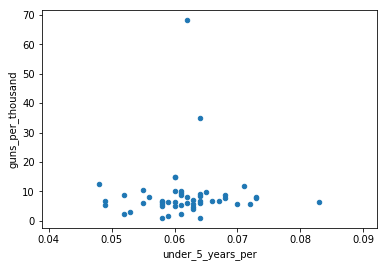

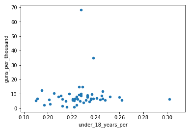

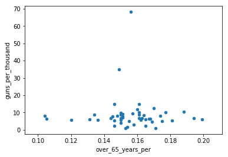

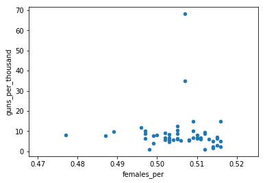

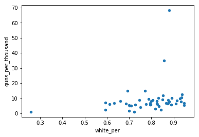

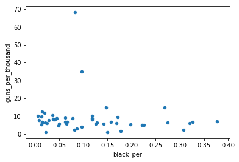

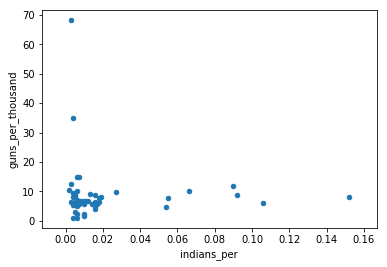

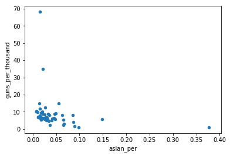

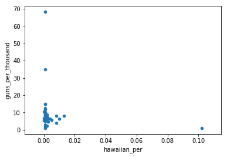

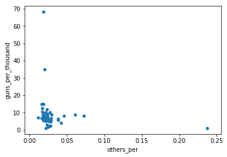

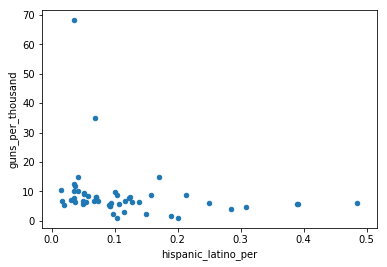

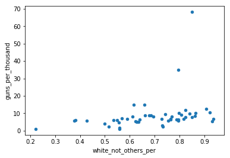

[2 more figures not shown]

```python
def plot_scatter():
    for i in df_merge.columns[2:-2]:
        df_merge.plot(kind= 'scatter', y='guns_per_thousand', x=i);
    return
plot_scatter()
```

In the figures above we got overshooting values of `guns_per_thousand`, I would like to eliminate those to get a better look at the correlations.

Dropping the overshooting values of `guns_per_thousand` (over 20) to get a better scatter diagrames

```python
df_merge.drop(df_merge[df_merge.guns_per_thousand>20].index, inplace =True)
```

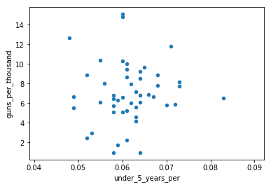

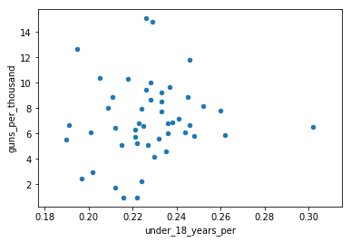

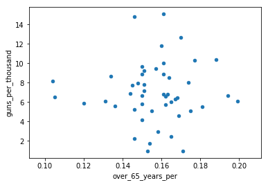

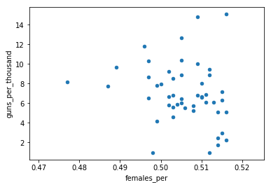

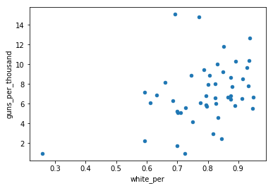

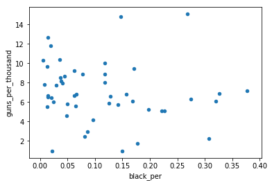

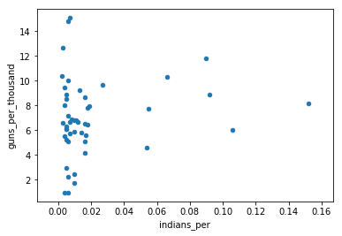

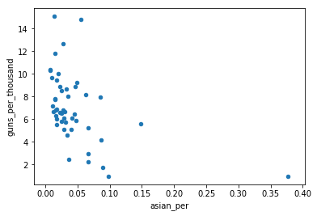

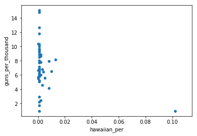

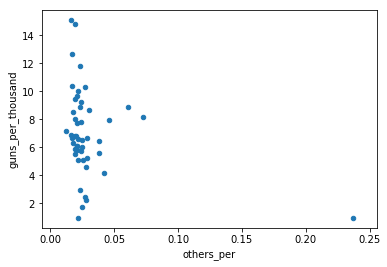

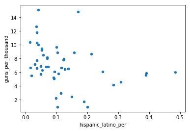

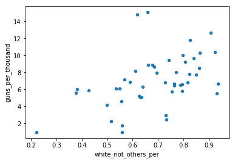

[2 more figures not shown]

```python
plot_scatter()
```